# BA 64060 Final Exam

# Determine the best value for k using an “elbow” chart

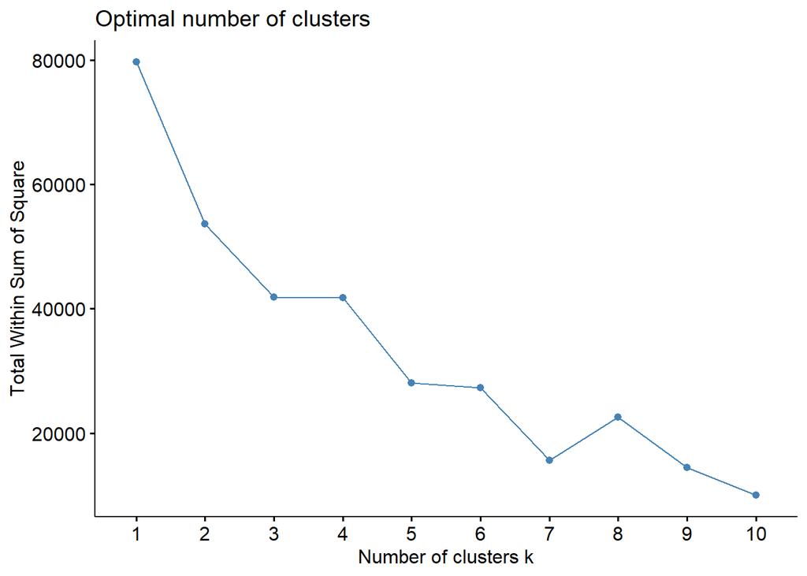

```r
fviz_nbclust(fuel.ds4, kmeans, method = "wss")
```

# The output above displays that around 4 or 5 is the ideal value for k (slope stops being as steep)

# Determine the best value for k using the Silhouette Method; compare to “elbow” chart results

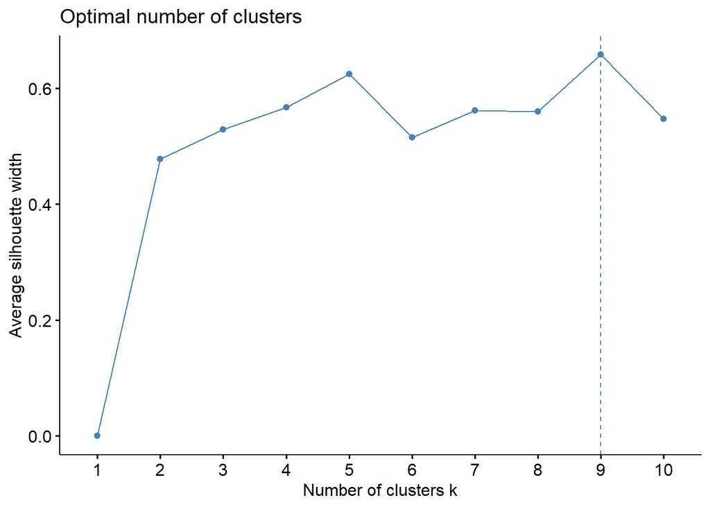

```r
fviz_nbclust(fuel.ds4, kmeans, method = "silhouette")
```

# The silhouette chart displays that 9 is the ideal value for k, which contradicts the elbow chart. The silhoutte chart also displays that 5 is the next best value for k. I’m selecting k = 5 given both charts show it as an optimal value.

# Run k-means using k = 5, number of restarts = 25

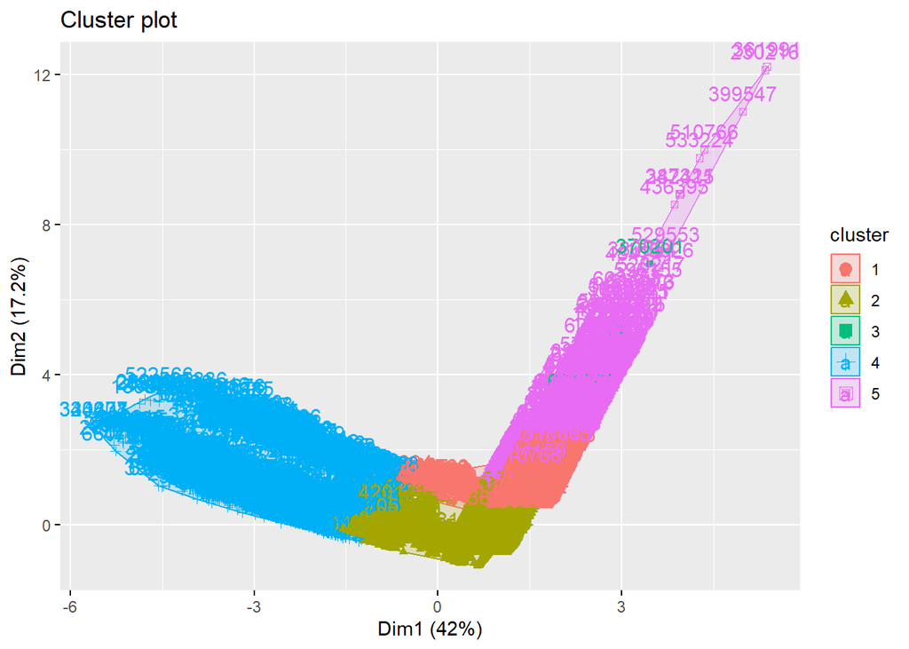

```r
set.seed(12)
fuel_k1 <- kmeans(fuel.ds4, centers = 5, nstart = 25)
fviz_cluster(fuel_k1, data = fuel.ds4)
```

```r
fuel_k1$cluster
```

[output not shown]

[output cut: 2399 more lines]

```r
fuel_k1$size
```

```
## [1] 2950 6572    2 3118  629
```

# After viewing the cluster plot based on k = 5, I see that cluster 3 contains only 2 records and they are buried on the cluster plot. I’m going to rerun the clustering analysis with varying values of k and see how that affects the output.